# statisticsPt4

## Part 4. Multivariate Statistics

$$ \def\pr{\hbox{Pr}} \def\var{\hbox{var}} \def\cov{\hbox{cov}} \def\corr{\hbox{corr}} \def\dmX{\un{\mathcal{X}}} \def\dmG{\un{\mathcal{G}}} \def\dmK{\un{\mathcal{K}}} \def\dmS{\un{\mathcal{S}}} \def\dmC{\un{\mathcal{C}}} \def\dmZ{\un{\mathcal{Z}}} \def\bma{{\mbox{\boldmath $\alpha$}}} \def\bmb{{\mbox{\boldmath $\beta$}}} \def\bmu{{\mbox{\boldmath $\mu$}}} \def\bme{{\mbox{\boldmath $\epsilon$}}} \def\bmS{{\mbox{\boldmath $\Sigma$}}} \def\bmL{{\mbox{\boldmath $\Lambda$}}} \def\bmd{{\mbox{\boldmath $\delta$}}} \def\bmD{{\mbox{\boldmath $\Delta$}}} \def\bmG{{\mbox{\boldmath $\Gamma$}}} \def\bmphi{{\mbox{\boldmath $\phi$}}} \def\bmPhi{{\mbox{\boldmath $\Phi$}}} \def\bmpsi{{\mbox{\boldmath $\psi$}}} \def\bmtheta{{\mbox{\boldmath $\theta$}}} \def\eq{\begin{equation}} \def\eeq{\end{equation}} \def\i{{\bf i}} \def\un#1{{\bf #1}}$$

The *mean* of the random vector $\un Z$ is the vector of mean values of $Z_1$ and~$Z_2$,

$$ \langle \un Z\rangle = \pmatrix{\langle Z_1\rangle \cr \langle Z_2\rangle}. $$

The *covariance* of random variables $Z_1$ and $Z_2$ is a measure of how their realizations are dependent upon each other and is defined to be the mean of the random variable

$$(Z_1-\langle Z_1\rangle)(Z_2-\langle Z_2\rangle),$$

i.e.,

$$ \cov(Z_1,Z_2) = \left\langle\ (Z_1-\langle Z_1\rangle)(Z_2-\langle Z_2\rangle)\ \right\rangle. $$

Two simple consequences of the definition of covariance are:

$$\eqalign{ \cov(Z_1,Z_2) &= \langle Z_1 Z_2\rangle - \langle Z_1\rangle\langle Z_2\rangle \cr \cov(Z_1,Z_1) &= \var(Z_1).} $$

The *correlation* of $Z_1$ and $Z_2$ is defined by

$$ \rho_{12} = {\cov(Z_1,Z_2)\over\sqrt{\var(Z_1)\var(Z_2)}}. $$

The correlation is unitless and restricted to values

$$-1\le \rho_{12}\le 1.$$

If $|\rho_{12}|=1$, then $Z_1$ and $Z_2$ are *linearly dependent*.

### Covariance matrix

Let $\un a = (a_1,a_2)^\top$ be any constant vector. Then the variance of the random variable $\un a^\top\un Z = a_1Z_1+a_2Z_2$ is given by

$$\eqalign{ \var(\un a^\top \un Z) &= \cov(a_1Z_1+a_2Z_2,a_1Z_1+a_2Z_2)\cr &=a_1^2\var(Z_1)+a_1a_2\cov(Z_1,Z_2)+a_1a_2\cov(Z_2,Z_1)+a_2^2\var(Z_2)\cr &=(a_1,a_2) \pmatrix{\var(Z_1)&\cov(Z_1,Z_2)\cr\cov(Z_2,Z_1)&\var(Z_2)} \pmatrix{a_1\cr a_2}.} $$

The matrix in the above equation is the *variance-covariance matrix* $\bf\Sigma$, i.e.,

$$ {\bf\Sigma} = \pmatrix{\var(Z_1)&\cov(Z_1,Z_2)\cr\cov(Z_2,Z_1)&\var(Z_2)}. $$

Therefore

$$ \var(\un a^\top \un Z) = \un a^\top\bf\Sigma\un a. $$

Note that $\bf\Sigma$ is *symmetric*, i.e.,

$$ \bf\Sigma^\top = \bf\Sigma $$

and *postive definite*, that is, for any real vector $\un a$,

$$ \un a^\top\bf\Sigma\un a > 0. $$

$\un a^\top\bf\Sigma\un a $ is called a *quadratic form*.

The covariance matrix can be written as an outer product:

$$ \bf\Sigma=\langle\ (\un Z-\langle\un Z\rangle)(\un Z-\langle\un Z\rangle)^\top\ \rangle = \langle\un Z\un Z^\top\rangle -\langle\un Z\rangle\langle\un Z\rangle^\top. $$

For example

$$ \left\langle\pmatrix{Z_1-\langle Z_1\rangle\cr Z_2-\langle Z_2\rangle} (Z_1-\langle Z_1\rangle,Z_2-\langle Z_2\rangle)\right\rangle $$$$ =\left\langle \pmatrix{(Z_1-\langle Z_1\rangle)^2 & (Z_1-\langle Z_1\rangle)(Z_2-\langle Z_2\rangle)\cr (Z_2-\langle Z_2\rangle)(Z_1-\langle Z_1\rangle) & (Z_2-\langle Z_2\rangle)^2 }\right\rangle $$$$ = \pmatrix{\var(Z_1)&\cov(Z_1,Z_2)\cr\cov(Z_2,Z_1)&\var(Z_2)} $$

If $\langle\un Z\rangle=\un 0$, we can write simply

$$ \bf\Sigma=\langle \un Z\un Z^\top\rangle. $$

A random vector $\un Z=(Z_1,Z_2)^\top$ is often described by a {\it multivariate normal density function} $p(\un z)$, given by

$$ p(\un z) = {1\over (2\pi)^{N/2}\sqrt{|\bf\Sigma|}} \exp\left(-{1\over 2}(\un z-\bf\mu)^\top \bf\Sigma^{-1} (\un z-\bf\mu)\right), $$

in this case $N=2$.

In analogy to the univariate case,

$$ \langle\un Z\rangle = \bf\mu,\quad \langle\ (\un Z-\langle\un Z\rangle)(\un Z-\langle\un Z\rangle)^\top\ \rangle = \bf\Sigma. $$

We write $$ \un Z \sim \mathcal{N}(\bf\mu,\bf\Sigma). $$

**Theorem:**

If two random variables $Z_1,Z_2$ have a bivariate normal distribution, they are independent if and only if $\rho_{12}=0$, that is, if and only if they are uncorrelated.

In general a zero correlation does not imply that two random variables are independent. However this theorem says that it does if the variables are normally distributed.

### Parameter estimation

In the multivariate case, the sample functions of interest are those which can be used to estimate the vector mean and variance-covariance matrix of a distribution $P(\un z)$. These are the *sample mean vector*

$$ \bar{\un Z} = {1\over n}\sum_{i=1}^n\un Z(i) $$

and the *sample variance-covariance matrix*

$$ \un S = {1\over n-1}\sum_{i=1}^n( \un Z(i) - \bar{\un Z} ) (\un Z(i) - \bar{\un Z})^\top. $$

As in the scalar case, these are unbiased estimators:

$$ \langle\bar{\un Z}\rangle = \langle\un Z\rangle\quad \langle\un S\rangle = \bf\Sigma $$

The sample mean vector

$$ \bar{\un Z} = {1\over n}\sum_{\nu=1}^n \un Z(\nu) $$

is multivariate normally distributed with mean $\bf\mu$ and covariance matrix $\bf\Sigma/n$.

For zero-mean random vectors $\un Z_i$, let

$$ \un X = (n-1)\un S = \sum_{\nu=1}^n \un Z(\nu)\un Z(\nu)^\top $$

The probability density function of $\un X$ is the *Wishart density with $n$ degrees of freedom*

$$ p_W(\un x) ={|\un x|^{(n-N-1)/2}\exp(-{\rm tr}(\bf\Sigma^{-1}\un x)/2) \over 2^{Nn/2}\pi^{N(N-1)/4}|\bf\Sigma|^{n/2}\prod_{i=1}^N\Gamma[(n+1-i)/2]} $$

for $\un x$ positive definite, and $0$ otherwise.

**Exercise 1:**

Show that the Wishart distribution with $n$ degrees of freedom reduces to the chi-square distribution with $n$ degrees of freedom in the univariate case $\un Z \to Z$ and $\bf\Sigma\to\sigma^2\to 1$.

### Principal Components Analysis

The principal components transformation generates linear combinations of multivariate observations which have *maximum variance*.

Consider a set of measurements represented by the random vector $\un Z$ and assume that $\langle\un Z\rangle=\un 0$, so that the covariance matrix is

$$\bf\Sigma=\langle\un Z \un Z^\top\rangle.$$

We seek a linear combination $Y = \un a^\top \un Z$ whose variance is maximum. Remember

$$ \var(Y)=\un a^\top \bf\Sigma \un a. $$

The maximization only makes sense if we restrict $\un a$ in some way. A convenient constraint is $\un a^\top \un a=1$. So we maximize the Lagrange function

$$ L = \un a^\top \bf\Sigma \un a - \lambda(\un a^\top \un a - 1). $$

Taking the derivative,

$$ {\partial L \over \partial \un a} = 2\bf\Sigma\un a - 2\lambda\un a = \un 0. $$

This is the eigenvalue problem

$$ \bf\Sigma\un a = \lambda\un a $$

for the symmetric, positive definite matrix $\bf\Sigma$.

Call the (orthogonal and normalized) eigenvectors $\un a_1\dots \un a_N$. Assume that they are sorted according to decreasing eigenvalue

$$\lambda_1\ge \dots\ge\lambda_N.$$

These eigenvectors are the *principal axes* and the corresponding linear combinations $\un a_i^\top\un Z$ are projections along the principal axes, called the *principal components* of $\un Z$.

The individual principal components

$$ Y_1 = \un a_1^\top\un Z,\ Y_2=\un a_2^\top\un Z,\ \dots,\ Y_N=\un a_N^\top\un Z $$

can be expressed more compactly as a random vector $\un Y$ by writing

$$ \un Y = \un A^\top\un Z, $$

where $\un A$ is the matrix whose columns comprise the eigenvectors, that is,

$$ \un A = (\un a_1\dots \un a_N). $$

Since the eigenvectors are orthogonal and normalized, $\un A$ is an orthonormal matrix:

$$ \un A^\top \un A=\un I. $$

If the covariance matrix of the principal components vector $\un Y$ is called $\bf\Sigma'$, then we have

$$ \bf\Sigma' = \langle \un Y \un Y^\top \rangle= \langle\un A^\top \un Z \un Z^\top \un A\rangle =\un A^\top \bf\Sigma \un A = \pmatrix{\lambda_1 & 0 & \cdots &0\cr 0 &\lambda_2& \cdots&0\cr \vdots&\vdots&\ddots&\vdots\cr 0 & 0& \cdots&\lambda_N} $$

or

$$ \un A^\top \bf\Sigma \un A = \bf\Lambda $$

*The eigenvalues are thus seen to be the variances of the principal components, and all of the covariances are zero.*

The first principal component $Y_1$ has maximum variance

$$\var(Y_1)=\lambda_1,$$

the second principal component $Y_2$ has maximum variance

$$\var(Y_2)=\lambda_2$$

subject to the condition that it is uncorrelated with $Y_1$, and so on. The fraction of the total variance in the original dataset which is accounted for by the first $r$ principal components is

$$ {\lambda_1+\dots +\lambda_r\over\lambda_1+\dots +\lambda_r+\dots +\lambda_N} = {\lambda_1+\dots +\lambda_r \over\ {\rm tr} \bf\Lambda}. $$

### Data design matrix

Suppose that we have made independent observations $\un z(i)$ of $\un Z(i)$, $i=1\dots n$. These may be arranged into an $n\times \texttt{}N$ matrix $\dmZ$ in which each $N$-component observation vector forms a row, i.e.,

$$ \dmZ = \pmatrix{\un z(1)^\top \cr \un z(2)^\top\cr\vdots\cr\un z(n)^\top}, $$

This is a very useful construct for computer programs.

For two-dimensional observations $$ \un z(i) = \pmatrix{z_1(i)\cr z_2(i)} = (z_1(i), z_2(i))^\top,\quad i = 1\dots n $$

Mean $$ \bar z_1 = {1\over n}\sum_{i=1}^n z_1(i),\quad \bar z_2= {1\over n}\sum_{i=1}^n z_2(i) $$

$$ \bar{\un z} = \pmatrix{\bar z_1 \cr \bar z_2} = {1\over n}\pmatrix{z_1(1) & z_1(2) & \cdots & z_1(n)\cr z_2(1) & z_2(2) & \cdots & z_2(n)} \pmatrix {1\cr 1\cr \vdots\cr 1} = {1\over n}\dmZ^\top\un 1_n $$

Covariance matrix $$ {\bf\Sigma} = {1\over n-1}\pmatrix{ \sum_i(z_1(i)-\bar z_1)^2 & \sum_i (z_1(i)-\bar z_1)(z_2(i)-\bar z_2) \cr \sum_i (z_1(i)-\bar z_1)(z_2(i)-\bar z_2) & \sum_i(z_2(i)-\bar z_2)^2 } $$

Data matrix $$ \dmZ =\pmatrix{z_1(1) &z_2(1) \cr z_1(2) & z_2(2) \cr \vdots & \vdots \cr z_1(n) & z_2(n)} $$

*Column centered* data matrix

$$ \tilde\dmZ =\pmatrix{z_1(1)-\bar z_1 & z_2(1) -\bar z_2 \cr z_1(2)-\bar z_1& z_2(2)-\bar z_2 \cr \vdots & \vdots \cr z_1(n)-\bar z_1 & z_2(n) -\bar z_2} $$

So the covariance matrix estimate can be written as

$$ \un s = {1\over n-1}\tilde\dmZ^\top\tilde\dmZ $$

**Exercise 2:**

(a) Show that the covariance matrix estimate can also be written in the form

$$ (n-1)\un s = \dmZ^\top\un H\dmZ, $$

where the symmetric *centering matrix* $\un H$ is given by

$$ \un H = \un I_{nn} - {1\over n}\un 1_n \un 1_n^\top. $$

(b) Show that the matrix $\un H$ is *idempotent*, i.e., $$ \un H \un H = \un H. $$

Let $\un x$ be any $n$-component vector. Then $$ \un x^\top\un s\un x = {1\over n-1} \un x^\top\dmZ^\top\un H\dmZ\un x = {1\over n-1} \un x^\top\dmZ^\top\un H\un H\dmZ\un x = {1\over m-1}\un y^\top\un y \ge 0, $$ where $\un y = \un H\dmZ\un x$. Therefore $\un s$ is positive semi-definite.

So in practice, one estimates the covariance matrix $\bf\Sigma$ in terms of the data matrix $\dmZ$, and then solves the eigenvalue problem in the form

$$ \un s\un a = {1\over n-1}\dmZ^\top\dmZ\un a = \lambda\un a. $$

Alternatively, consider the SVD of the $m\times N$ data matrix $\dmZ$:

$$\dmZ = \un U\un W\un V^\top,\quad \un U^\top\un U = \un V^\top\un V = \un I,\ \un W\hbox{ is diagonal}.$$

Then

$$\eqalign{ (m-1)\bf\Sigma &= \dmZ^\top\dmZ = \un V\un W\un U^\top\un U\un W\un V^\top\cr &= \un V \un W^2\un V^\top }$$

or

$$\un V^\top\bf\Sigma\un V = {1\over m-1}\un W^2 = \bf\Lambda,$$

so $\un V$ is the matrix of eigenvectors and the eigenvalues are proportional to the squares of the diagonal elements of W.

**Example:** (“Factor analysis”)

We had for the principal components transformation

$$\un Y = \un A^\top\un Z$$

and we can recover the original variables by inverting,

$$\un Z = (\un A^\top)^{-1}\un Y = \un A \un Y.$$

Suppose that the first $r$ PCs account for (explain) most of the variance in the data and let $\un A = (\un A_r,\un A_{r-})$, where

$$\un A_r = (\un a_1,\dots \un a_r),\quad \un A_{r-} = (\un a_{r+1},\dots \un a_N),$$

and similarly

$$\un Y =\pmatrix{\un Y_r \cr \un Y_{r-}}.$$

Now reconstruct $\un Z$ from $\un Y_r = (Y_1\dots Y_r)^\top$:

$$\un Z \approx \un A_r \un Y_r.$$

The *reconstruction error* is

$$\bf\epsilon = \un Z - \un A_r \un Y_r = \un Z - \un A_r \un A_r^\top \un Z = (\un I - \un A_r \un A_r^\top)\un Z = \un A_{r-}\un A_{r-}^\top \un Z,$$

so we can write

$$\un Z = \un A_r\un Y_r + \bf\epsilon.$$

This is in the form of a *factor analysis model*. In this case the “factors” are the first $r$ principal components. The elements of $\un A_r$ are called the “factor loadings”.

The variance-covariance matrix for the error term is

$$\eqalign{ \langle \bf\epsilon\bf\epsilon^\top\rangle &= \langle\un A_{r-}\un A_{r-}^\top\un Z\un Z^\top\un A_{r-}\un A_{r-}^\top\rangle \cr &= \langle\un A_{r-}\un Y_{r-}\un Y_{r-}^\top\un A_{r-}\rangle \cr &= \un A_{r-}\un \bf\Lambda_{r-}\un A_{r-}^\top.}$$

```python
%matplotlib inline
```

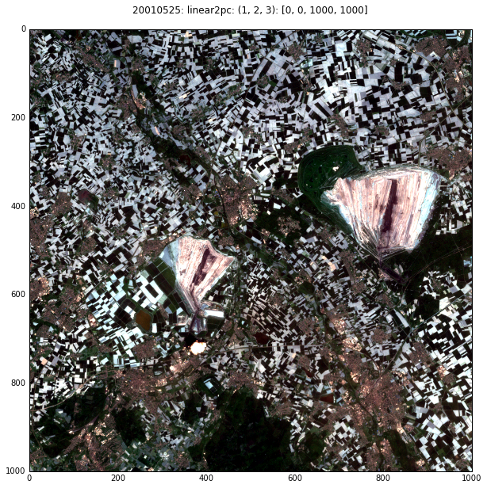

```python
run dispms -f 20010525 -e 3 -p [1,2,3]
```

```
------------PCA ---------------
Wed Oct 26 16:03:04 2016
Input /home/mort/stats2016/20010525
Eigenvalues: [  6.53264847e+03   3.94881303e+02   1.39378715e+02   3.23104634e+01
   1.48719152e+01   3.02456833e+00]
```

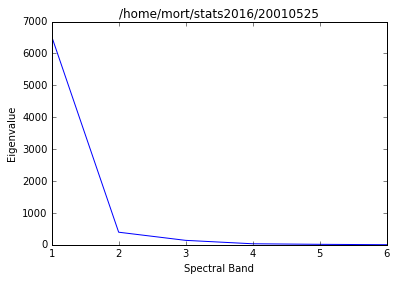

```
result written to: /home/mort/stats2016/20010525_pca
elapsed time: 0.387809991837
```

```python
run pca /home/mort/stats2016/20010525
```

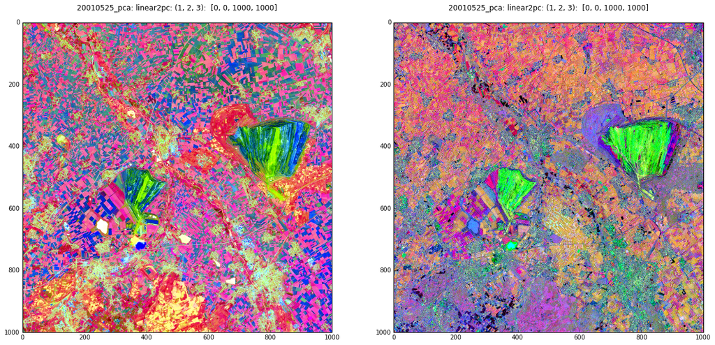

```python
run dispms -f /home/mort/stats2016/20010525_pca -p [1,2,3] -e 3 \
-F /home/mort/stats2016/20010525_pca -P [4,5,6] -E 3
```